# Project One: Multiple Regression, Qualitative Variables Interactions, Quadratic Regression

For Project One, you have been asked to create different regression models analyzing a housing data set. Before beginning work on the project, be sure to read through the Project One Guidelines and Rubric to understand what you need to do and how you will be graded on this assignment. Be sure to carefully review the Project One Summary Report template, which contains all of the questions that you will need to answer about the regression analyses you are performing.

For this project, you will be writing all the scripts yourself. You may reference the textbook and your previous work on the problem sets to help you write the scripts.

### Scenario

You are a data analyst working for a real estate company. You have access to a large set of historical data that you can use to analyze relationships between different attributes of a house (such as square footage or the number of bathrooms) and the house’s selling price. You have been asked to create different regression models to predict sale prices for houses based on critical variable factors. These regression models will help your company set better prices when listing a home for a client. Setting better prices will ensure that listings can be sold within a reasonable amount of time.

There are several variables in this data set, but you will be working with the following important variables:

| Variable | What does it represent? |
| --- | --- |
| price | Sale price of the home |
| bedrooms | Number of bedrooms |
| bathrooms | Number of bathrooms |
| sqft_living | Size of the living area in sqft |
| sqft_above | Size of the upper level in sqft |
| sqft_lot | Size of the lot in sqft |
| age | Age of the home |
| grade | Measure of craftsmanship and the quality of materials used to build the home |
| appliance_age | Average age of all appliances in the home |
| crime | Crime rate per 100,000 people |
| backyard | Home has a backyard (backyard=1) or not (backyard=0) |
| school_rating | Average rating of schools in the area |
| view | Home backs out to a lake (view=2), backs out to trees (view=1), or backs out to a road (view=0) |

# Prepare Your Data Set

In the following code block, you have been given the R code to prepare your data set.

Click the **Run** button on the toolbar to run this code.

```r
housing <- read.csv(file="housing_v2.csv", header=TRUE, sep=",")

# converting appropriate variables to factors
housing_fctrd <- within(housing, {
   view <- factor(view)
   backyard <- factor(backyard)
   renovated <- factor(renovated)
})

# number of columns
ncol(housing_fctrd)

# number of rows
nrow(housing_fctrd)
```

23

2692

# Model #1 - First Order Regression Model with Quantitative and Qualitative Variables

You have been asked to create a first order regression model for *price* as the response variable, and *sqft_living*, *sqft_above*, *age*, *bathrooms*, and *view* as predictor variables. Before writing any code, review Section 3 of the Summary Report template to see the questions you will be answering about your first order multiple regression model.

Run your scripts to get the outputs of your regression analysis. Then use the outputs to answer the questions in your summary report.

**Note: Use the + (plus) button to add new code blocks, if needed.**

```
[1] "Dataset Preview:"
```

A data.frame: 5 × 23

| id <int> | price <int> | bedrooms <int> | bathrooms <dbl> | sqft_living <int> | sqft_lot <int> | floors <dbl> | backyard <fct> | view <fct> | condition <int> | ⋯ | yr_built <int> | yr_renovated <int> | renovated <fct> | zipcode <int> | sqft_living15 <int> | sqft_lot15 <int> | age <int> | appliance_age <dbl> | crime <int> | school_rating <dbl> |
| --- | --- | --- | --- | --- | --- | --- | --- | --- | --- | --- | --- | --- | --- | --- | --- | --- | --- | --- | --- | --- |
| 1 | 325000 | 3 | 2.25 | 1570 | 43350 | 1.0 | 0 | 2 | 4 | ⋯ | 1967 | 0 | 0 | 98022 | 1570 | 220849 | 48 | 17.7 | 138 | 5.27 |
| 2 | 745000 | 5 | 3.00 | 2400 | 10126 | 2.0 | 0 | 2 | 3 | ⋯ | 1981 | 0 | 0 | 98126 | 2250 | 3946 | 34 | 3.2 | 101 | 9.14 |
| 3 | 571000 | 4 | 1.00 | 1350 | 4000 | 1.5 | 0 | 0 | 3 | ⋯ | 1930 | 0 | 0 | 98117 | 1520 | 4000 | 85 | 7.6 | 110 | 7.97 |
| 4 | 395000 | 2 | 2.00 | 1960 | 4018 | 1.0 | 0 | 0 | 5 | ⋯ | 1950 | 0 | 0 | 98108 | 1240 | 4641 | 65 | 13.0 | 118 | 6.52 |
| 5 | 449950 | 3 | 1.75 | 1470 | 7590 | 1.0 | 0 | 0 | 3 | ⋯ | 1988 | 0 | 0 | 98117 | 1700 | 5080 | 27 | 6.8 | 98 | 8.18 |

```
[1] "housing_subset"
```

A data.frame: 5 × 3

| price <int> | sqft_living <int> | age <int> |
| --- | --- | --- |
| 325000 | 1570 | 48 |
| 745000 | 2400 | 34 |
| 571000 | 1350 | 85 |
| 395000 | 1960 | 65 |
| 449950 | 1470 | 27 |

```
Correlation Analysis:
```

A matrix: 3 × 3 of type dbl

|  | price | sqft_living | age |
| --- | --- | --- | --- |
| price | 1.0000 | 0.6895 | -0.0746 |
| sqft_living | 0.6895 | 1.0000 | -0.3547 |
| age | -0.0746 | -0.3547 | 1.0000 |

```
[1] "Correlation between Price and Living Area: r = 0.689 suggests a moderate to strong positive relationship."
This means that as living area increases, price tends to increase as well.

[1] "Correlation between Price and Age: r = -0.075 suggests a very weak negative relationship."
This means that as the age of the home increases, the price tends to decrease slightly.
```

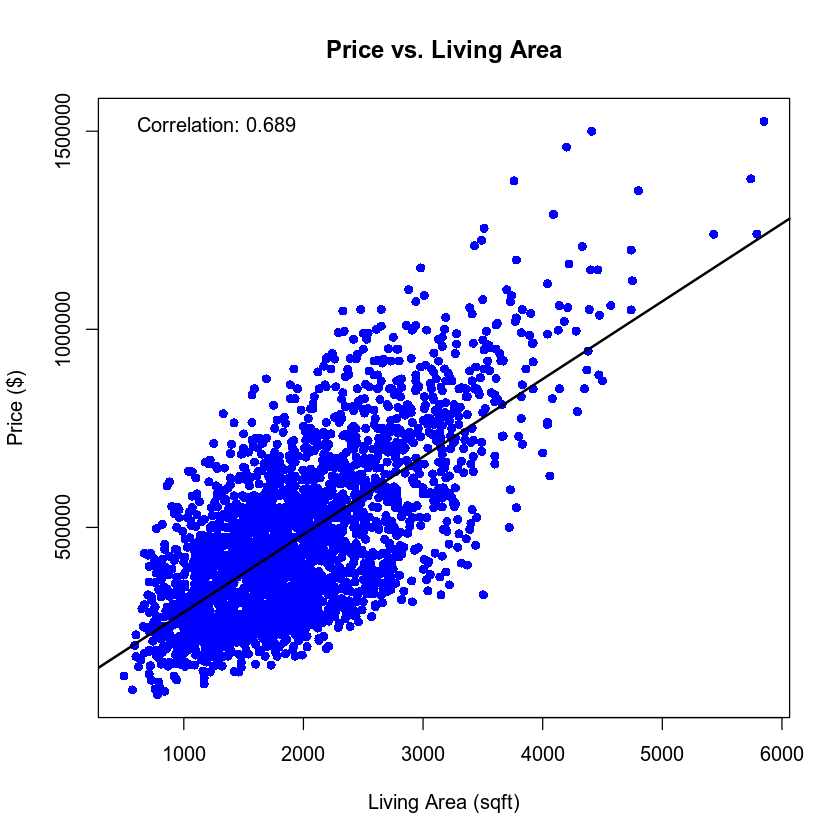

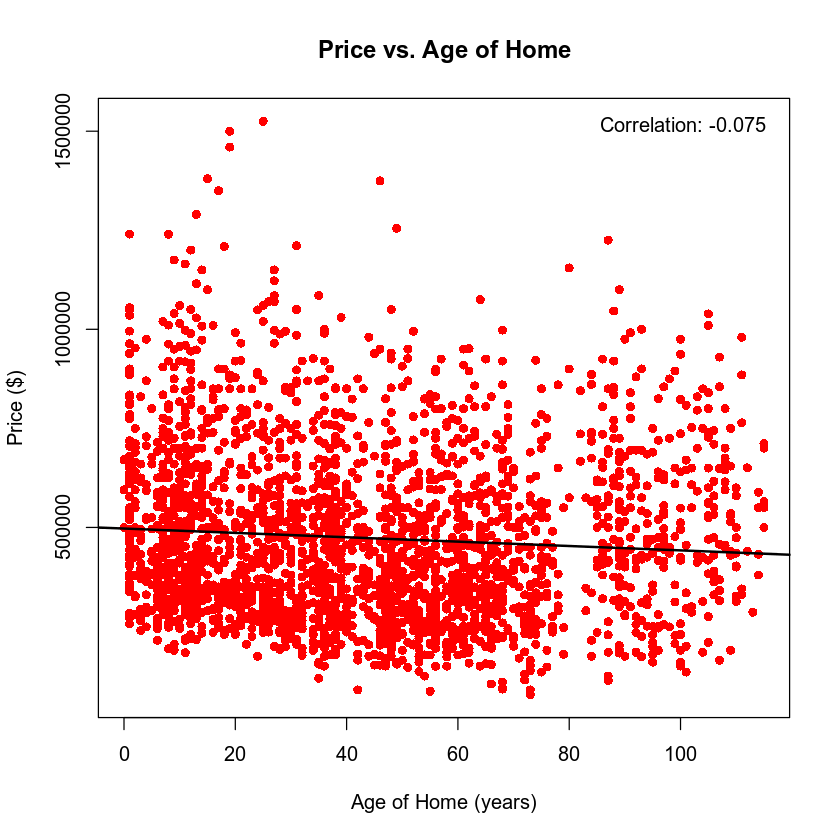

```r
# Print the first five rows
print("Dataset Preview:")
head(housing_fctrd, 5)

# Subset the original data set to select some variables and create a new data set
housing_vars <- c("price","sqft_living","age")
housing_subset <- housing_fctrd[housing_vars]

# Privew the housing_subset
print("housing_subset")
head(housing_subset, 5)

# Display the correlation matrix
cat("\nCorrelation Analysis:")
corr_matrix <- cor(housing_subset, method = "pearson")
round(corr_matrix, 4)
cat("\n")

cor_price_sqft <- cor(housing_subset$price, housing_subset$sqft_living, method = "pearson")
print(paste("Correlation between Price and Living Area: r =", round(cor_price_sqft, 3), "suggests a moderate to strong positive relationship."))
cat("This means that as living area increases, price tends to increase as well.\n\n")

# Fit a linear model for price VS sqft_living
lm1 <- lm(price ~ sqft_living, data = housing_subset)

# Scatterplot: Price vs. Living Area
plot(housing_subset$sqft_living, housing_subset$price,
     main = "Price vs. Living Area",
     xlab = "Living Area (sqft)",
     ylab = "Price ($)",
     col = "blue", pch = 16)

# Add trendline to the plot
abline(lm1, col = "black", lwd = 2)
legend("topleft", legend = paste("Correlation:", round(cor_price_sqft, 3)), bty = "n")


cor_price_age <- cor(housing_subset$price, housing_subset$age, method = "pearson")
print(paste("Correlation between Price and Age: r =", round(cor_price_age, 3), "suggests a very weak negative relationship."))
cat("This means that as the age of the home increases, the price tends to decrease slightly.\n\n")

# Fit a linear model for price VS sqft_living
lm2 <- lm(price ~ age, data = housing_subset)

# Scatterplot: Price vs. Age of Home
plot(housing_subset$age, housing_subset$price,
     main = "Price vs. Age of Home",
     xlab = "Age of Home (years)",
     ylab = "Price ($)",
     col = "red", pch = 16)

# Add trendline to the plot
abline(lm2, col = "black", lwd = 2)
legend("topright", legend = paste("Correlation:", round(cor_price_age, 3)), bty = "n")
```

```
Housing subset with six variables:
```

A data.frame: 5 × 6

| price <int> | sqft_living <int> | sqft_above <int> | age <int> | bathrooms <dbl> | view <fct> |
| --- | --- | --- | --- | --- | --- |
| 325000 | 1570 | 1570 | 48 | 2.25 | 2 |
| 745000 | 2400 | 2400 | 34 | 3.00 | 2 |
| 571000 | 1350 | 1350 | 85 | 1.00 | 0 |
| 395000 | 1960 | 980 | 65 | 2.00 | 0 |
| 449950 | 1470 | 1470 | 27 | 1.75 | 0 |

```
Call:
lm(formula = price ~ sqft_living + sqft_above + age + bathrooms +
    view, data = housing_subset_6)

Residuals:
    Min      1Q  Median      3Q     Max
-419299 -101792   -5606   93896  489323

Coefficients:
             Estimate Std. Error t value Pr(>|t|)
(Intercept) 7.709e+03  1.411e+04   0.546  0.58495
sqft_living 1.293e+02  8.123e+00  15.916  < 2e-16 ***
sqft_above  1.951e+01  7.458e+00   2.616  0.00894 **
age         1.451e+03  1.199e+02  12.098  < 2e-16 ***
bathrooms   4.397e+04  6.126e+03   7.178 9.13e-13 ***
view1       1.675e+05  1.071e+04  15.640  < 2e-16 ***
view2       2.490e+05  1.201e+04  20.739  < 2e-16 ***
---
Signif. codes:  0 '***' 0.001 '**' 0.01 '*' 0.05 '.' 0.1 ' ' 1

Residual standard error: 133600 on 2685 degrees of freedom
Multiple R-squared:  0.6029,	Adjusted R-squared:  0.602
F-statistic: 679.3 on 6 and 2685 DF,  p-value: < 2.2e-16
```

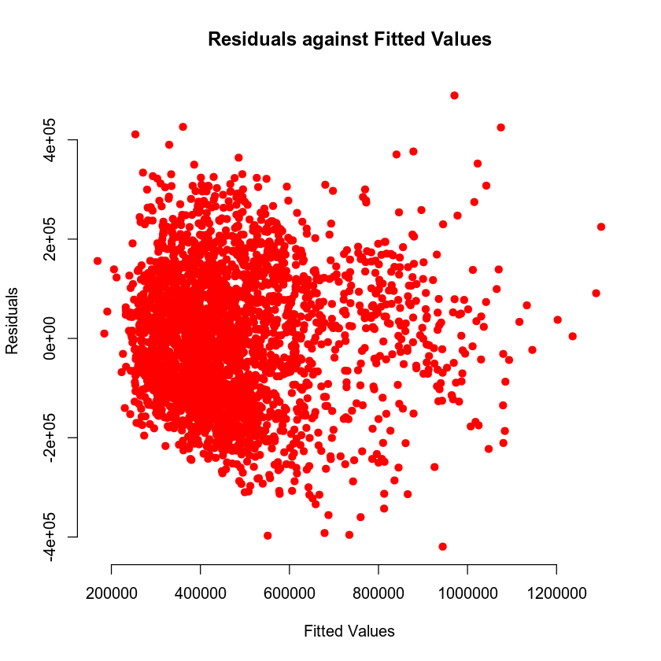

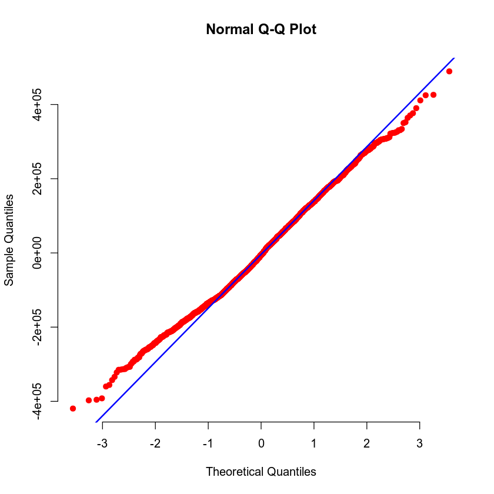

```r
# Create a combined model and report the results:
# ===============================================

# Subset the original data set to select more variables and create a new data set
housing_6_vars <- c("price","sqft_living","sqft_above", "age", "bathrooms", "view")
housing_subset_6 <- housing_fctrd[housing_6_vars]

# Privew the housing_subset
cat("Housing subset with six variables:")
head(housing_subset_6, 5)

# Create the model
model6 <- lm(price ~ sqft_living + sqft_above + age + bathrooms + view, data=housing_subset_6)
summary(model6)

# Predicted values
# print("fitted values")
fitted_values <- fitted.values(model6)

# Residuals
# print("residuals")
residuals <- residuals(model6)

# Plot the fitted values and the Q-Q plots
plot(fitted_values, residuals,
     main = "Residuals against Fitted Values",
     xlab = "Fitted Values", ylab = "Residuals",
     col="red",
     pch = 19, frame = FALSE)

qqnorm(residuals, pch = 19, col="red", frame = FALSE)
qqline(residuals, col = "blue", lwd = 2)
```

```r
# Making Predictions Using Model:
# ===============================

# The predicted price for a home with 2150sqft living area, 1050sqft upper level, 15 years old W/3 bathrooms and no view.
newdata1 <- data.frame(sqft_living=2150, sqft_above=1050, age=15, bathrooms=3, view='0')

cat("prediction interval:")
price_prediction_pred_newdata1 <- predict(model6, newdata1, interval="predict", level=0.90)
round(price_prediction_pred_newdata1, 4)

cat("confidence interval:")
price_prediction_conf_newdata1 <- predict(model6, newdata1, interval="confidence", level=0.90)
round(price_prediction_conf_newdata1, 4)

# Extract 'fit' value from the matrix
fit_value <- round(price_prediction_conf_newdata1[1, 1], 0)
# Predict home price 1
Predict_model_1_1 <- round(7709 + 129.3*2150 + 19.51*1050 + 1451*15 + 43970*3 + 167500*0 + 249000*0, 0)

cat(paste("The predicted price for a home with 2150sqft living area, 1050sqft upper level, 15 years old W/3 bathrooms and no view is \napproximately $", Predict_model_1_1))
cat("\nThis can be obtained by plugging the living area, upper level, age, bathrooms, and view parameters into model's prediction \nequation:")
cat(" Estimated Home Price = 7709 + 129.3*2150 + 19.51*1050 + 1451*15 + 43970*3 + 167500*0 + 249000*0 =", Predict_model_1_1, "\n")

cat("\n\n\n")

# The predicted price for a home with 4250sqft living area, 2100sqft upper level, 5 years old W/5 bathrooms and view to a lake.
newdata2 <- data.frame(sqft_living=4250, sqft_above=2100, age=5, bathrooms=5, view='2')

cat("prediction interval:")
price_prediction_pred_newdata2 <- predict(model6, newdata2, interval="predict", level=0.90)
round(price_prediction_pred_newdata2, 4)

cat("confidence interval:")
price_prediction_conf_newdata2 <- predict(model6, newdata2, interval="confidence", level=0.90)
round(price_prediction_conf_newdata2, 4)

# Extract 'fit' value from the matrix
fit_value <- round(price_prediction_conf_newdata2[1, 1], 0)
# Predict home price 2
Predict_model_1_2 <- round(7709 + 129.3*4250 + 19.51*2100 + 1451*5 + 43970*5 + 167500*0 + 249000*1, 0)

cat(paste("The predicted price for a home with 4250sqft living area, 2100sqft upper level, 5 years old W/5 bathrooms and view to a lake is approximately $", Predict_model_1_2))
cat("\nThis can be obtained by plugging the living area, upper level, age, bathrooms, and view parameters into model's prediction \nequation:")
cat(" Estimated Home Price = 7709 + 129.3*2150 + 19.51*1050 + 1451*15 + 43970*3 + 167500*0 + 249000*0 =", Predict_model_1_2, "\n")
```

```
prediction interval:
```

A matrix: 1 × 3 of type dbl

| fit | lwr | upr |
| --- | --- | --- |
| 459828.2 | 239563 | 680093.4 |

```
confidence interval:
```

A matrix: 1 × 3 of type dbl

| fit | lwr | upr |
| --- | --- | --- |
| 459828.2 | 446087.9 | 473568.5 |

```
The predicted price for a home with 2150sqft living area, 1050sqft upper level, 15 years old W/3 bathrooms and no view is
approximately $ 459864
This can be obtained by plugging the living area, upper level, age, bathrooms, and view parameters into model's prediction
equation: Estimated Home Price = 7709 + 129.3*2150 + 19.51*1050 + 1451*15 + 43970*3 + 167500*0 + 249000*0 = 459864



prediction interval:
```

A matrix: 1 × 3 of type dbl

| fit | lwr | upr |
| --- | --- | --- |
| 1074285 | 852522.6 | 1296048 |

```
confidence interval:
```

A matrix: 1 × 3 of type dbl

| fit | lwr | upr |
| --- | --- | --- |
| 1074285 | 1045117 | 1103454 |

```
The predicted price for a home with 4250sqft living area, 2100sqft upper level, 5 years old W/5 bathrooms and view to a lake is approximately $ 1074310
This can be obtained by plugging the living area, upper level, age, bathrooms, and view parameters into model's prediction
equation: Estimated Home Price = 7709 + 129.3*2150 + 19.51*1050 + 1451*15 + 43970*3 + 167500*0 + 249000*0 = 1074310
```

# Model #2 - Complete Second Order Regression Model with Quantitative Variables

You have been asked to create a complete second order regression model for *price* as the response variable, and *school_rating* and *crime* as predictor variables. Before writing any code, review Section 4 of the Summary Report template to see the questions you will be answering about your complete second order multiple regression model.

Run your scripts to get the outputs of your regression analysis. Then use the outputs to answer the questions in your summary report.

**Note: Use the + (plus) button to add new code blocks, if needed.**

```
[1] "housing_subset_2"
```

A data.frame: 5 × 3

| price <int> | school_rating <dbl> | crime <int> |
| --- | --- | --- |
| 325000 | 5.27 | 138 |
| 745000 | 9.14 | 101 |
| 571000 | 7.97 | 110 |
| 395000 | 6.52 | 118 |
| 449950 | 8.18 | 98 |

```
Correlation Analysis:
```

A matrix: 3 × 3 of type dbl

|  | price | school_rating | crime |
| --- | --- | --- | --- |
| price | 1.0000 | 0.7860 | -0.7683 |
| school_rating | 0.7860 | 1.0000 | -0.6674 |
| crime | -0.7683 | -0.6674 | 1.0000 |

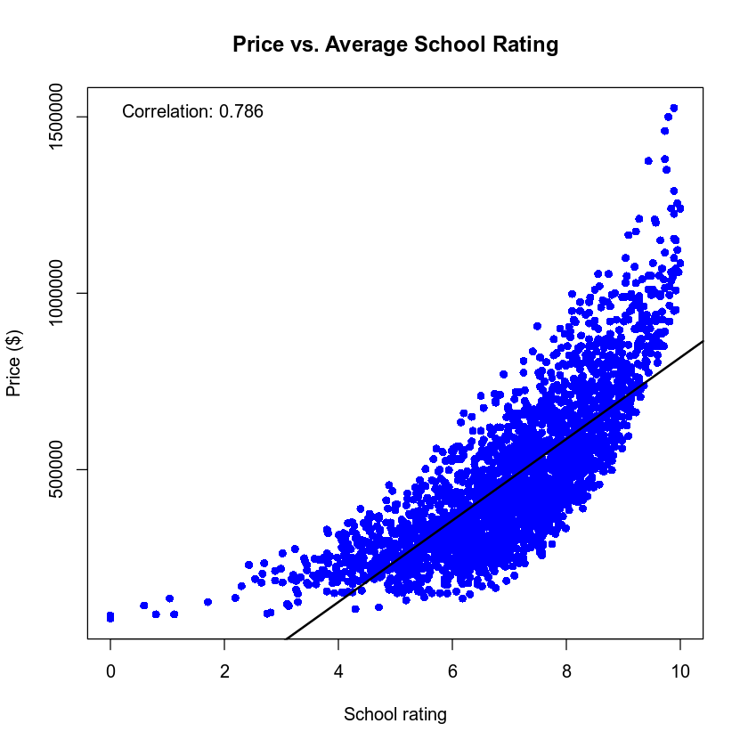

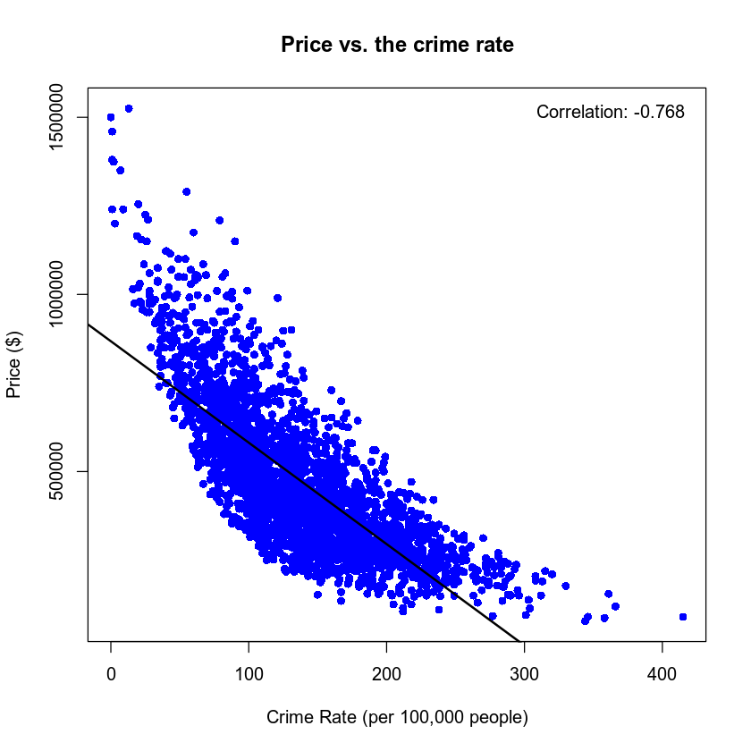

```r
# Subset the original data set to select some variables and create a new data set
housing_vars_2 <- c("price","school_rating","crime")
housing_subset_2 <- housing_fctrd[housing_vars_2]

# Privew the housing_subset
print("housing_subset_2")
head(housing_subset_2, 5)

# Display the correlation matrix
cat("\nCorrelation Analysis:")
corr_matrix_2 <- cor(housing_subset_2, method = "pearson")
round(corr_matrix_2, 4)
cat("\n")

# Find the correlation betwwen price and average school rating.
cor_price_school <- cor(housing_subset_2$price, housing_subset_2$school_rating, method = "pearson")

# Fit a linear model for price VS school_rating
lm_price_school <- lm(price ~ school_rating, data = housing_subset_2)

# Create scatterplots of price (price) vs. average school rating in the area (school_rating)
plot(housing_subset_2$school_rating, housing_subset_2$price,
     main = "Price vs. Average School Rating",
     xlab = "School rating",
     ylab = "Price ($)",
     col = "blue", pch = 16)

# Add trendline to the plot
abline(lm_price_school, col = "black", lwd = 2)

# Add correlation to the plot
legend("topleft", legend = paste("Correlation:", round(cor_price_school, 3)), bty = "n")


# Find the correlation betwwen price and crime
cor_price_crime <- cor(housing_subset_2$price, housing_subset_2$crime, method = "pearson")

# Fit a linear model for price VS crime
lm_price_crime <- lm(price ~ crime, data = housing_subset_2)

# Create scatterplots of price (price) vs. average school rating in the area (school_rating)
plot(housing_subset_2$crime, housing_subset_2$price,
     main = "Price vs. the crime rate",
     xlab = "Crime Rate (per 100,000 people)",
     ylab = "Price ($)",
     col = "blue", pch = 16)

# Add trendline to the plot
abline(lm_price_crime, col = "black", lwd = 2)

# Add correlation to the plot
legend("topright", legend = paste("Correlation:", round(cor_price_crime, 3)), bty = "n")
```

```
Call:
lm(formula = price ~ school_rating + crime + school_rating:crime +
    I(school_rating^2) + I(crime^2), data = housing_subset_2)

Residuals:
    Min      1Q  Median      3Q     Max
-340729  -61055   -6288   56875  427915

Coefficients:
                      Estimate Std. Error t value Pr(>|t|)
(Intercept)          7.339e+05  1.032e+05   7.113 1.45e-12 ***
school_rating       -7.375e+04  2.083e+04  -3.541 0.000406 ***
crime               -3.155e+03  5.235e+02  -6.027 1.90e-09 ***
I(school_rating^2)   1.165e+04  1.109e+03  10.497  < 2e-16 ***
I(crime^2)           6.377e+00  7.265e-01   8.777  < 2e-16 ***
school_rating:crime -5.227e+01  4.853e+01  -1.077 0.281513
---
Signif. codes:  0 '***' 0.001 '**' 0.01 '*' 0.05 '.' 0.1 ' ' 1

Residual standard error: 92690 on 2686 degrees of freedom
Multiple R-squared:  0.8088,	Adjusted R-squared:  0.8084
F-statistic:  2272 on 5 and 2686 DF,  p-value: < 2.2e-16
```

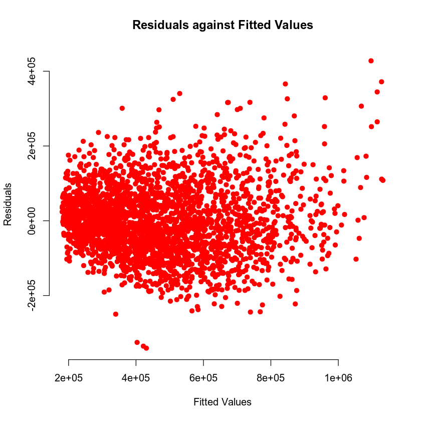

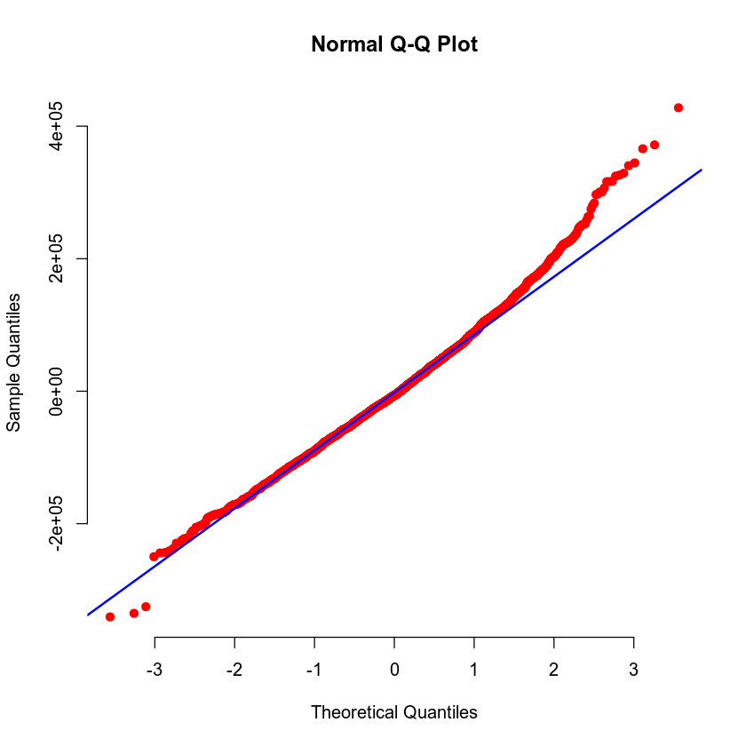

```r
# Create the second order regression model and print the statistics
model2_prc_schl_crm <- lm(price ~ school_rating + crime + school_rating:crime + I(school_rating^2) + I(crime^2) , data=housing_subset_2)
summary(model2_prc_schl_crm)

# Predicted values
# print("fitted values")
fitted_values_prc_schl_crm <- fitted.values(model2_prc_schl_crm)

# Residuals
# print("residuals")
residuals_values_prc_schl_crm <- residuals(model2_prc_schl_crm)

# Plot the fitted values and the Q-Q plots
plot(fitted_values_prc_schl_crm, residuals_values_prc_schl_crm,
     main = "Residuals against Fitted Values",
     xlab = "Fitted Values", ylab = "Residuals",
     col="red",
     pch = 19, frame = FALSE)

qqnorm(residuals_values_prc_schl_crm, pch = 19, col="red", frame = FALSE)
qqline(residuals_values_prc_schl_crm, col = "blue", lwd = 2)
```

```r
# Making Predictions Using Model:
# ===============================

# The predicted price for a home with average school rating of 9.80, and a crime rate of 81.02 per 100,000 individuals.
newdata1_prc_schl_crm <- data.frame(school_rating=9.80, crime=81.02)

cat("90% prediction interval:")
price_pred_prc_schl_crm1 <- predict(model2_prc_schl_crm, newdata1_prc_schl_crm, interval="predict", level=0.90)
round(price_pred_prc_schl_crm1, 4)

cat("90% confidence interval:")
price_conf_prc_schl_crm1 <- predict(model2_prc_schl_crm, newdata1_prc_schl_crm, interval="confidence", level=0.90)
round(price_conf_prc_schl_crm1, 4)

# Extract 'fit' value from the matrix
fit_value1 <- round(price_conf_prc_schl_crm1[1, 1], 0)

# Making Predictions Using Model
HomePriceEstimate <- round(733900-(73750*9.8)-(3155*81.02)-(52.27*9.8*81.02)+(11650*9.8^2)+(6.377*91.02^2), 0)

cat(paste("The predicted price for a home in an area with \naverage school rating of 9.80, and a crime rate of 81.02 is approximately $", HomePriceEstimate))
cat("\nThis can be obtained by plugging the school rating and crime rate into model's prediction equation:")
cat("\nEstimated Home Price = 733900-(73750*9.8)-(3155*81.02)-(52.27*9.8*81.02)+(11650*9.8^2)+(6.377*91.02^2) =", HomePriceEstimate, "\n")
cat("\n\n")


# The predicted price for a home with average school rating of 4.28, and a crime rate of 215.50 per 100,000 individuals.
newdata2_prc_schl_crm <- data.frame(school_rating=4.28, crime=215.50)

cat("90% prediction interval:")
price_pred_prc_schl_crm2 <- predict(model2_prc_schl_crm, newdata2_prc_schl_crm, interval="predict", level=0.90)
round(price_pred_prc_schl_crm2, 4)

cat("90% confidence interval:")
price_conf_prc_schl_crm2 <- predict(model2_prc_schl_crm, newdata2_prc_schl_crm, interval="confidence", level=0.90)
round(price_conf_prc_schl_crm2, 4)

# Extract 'fit' value from the matrix
fit_value2 <- round(price_conf_prc_schl_crm2[1, 1], 0)

# Making Predictions Using Model
HomePriceEstimate2 <- round(733900-(73750*4.28)-(3155*215.5)-(52.27*4.28*215.5)+(11650*4.28^2)+(6.377*215.5^2), 0)

cat(paste("The predicted price for a home in an area with \naverage school rating of 4.28, and a crime rate of 215.50 is approximately $", HomePriceEstimate2))
cat("\nThis can be obtained by plugging the school rating and crime rate into model's prediction equation:")
cat("\nEstimated Home Price = 733900-(73750*4.28)-(3155*215.5)-(52.27*4.28*215.5)+(11650*4.28^2)+(6.377*215.5^2) =", HomePriceEstimate2, "\n")
cat("\n\n")
```

```
90% prediction interval:
```

A matrix: 1 × 3 of type dbl

| fit | lwr | upr |
| --- | --- | --- |
| 874497 | 721606.2 | 1027388 |

```
90% confidence interval:
```

A matrix: 1 × 3 of type dbl

| fit | lwr | upr |
| --- | --- | --- |
| 874497 | 863681.4 | 885312.7 |

```
The predicted price for a home in an area with
average school rating of 9.80, and a crime rate of 81.02 is approximately $ 885727
This can be obtained by plugging the school rating and crime rate into model's prediction equation:
Estimated Home Price = 733900-(73750*9.8)-(3155*81.02)-(52.27*9.8*81.02)+(11650*9.8^2)+(6.377*91.02^2) = 885727


90% prediction interval:
```

A matrix: 1 × 3 of type dbl

| fit | lwr | upr |
| --- | --- | --- |
| 199706.7 | 46991.65 | 352421.7 |

```
90% confidence interval:
```

A matrix: 1 × 3 of type dbl

| fit | lwr | upr |
| --- | --- | --- |
| 199706.7 | 191753.5 | 207659.9 |

```
The predicted price for a home in an area with
average school rating of 4.28, and a crime rate of 215.50 is approximately $ 199696
This can be obtained by plugging the school rating and crime rate into model's prediction equation:
Estimated Home Price = 733900-(73750*4.28)-(3155*215.5)-(52.27*4.28*215.5)+(11650*4.28^2)+(6.377*215.5^2) = 199696
```

# Nested Models F-Test

You have been asked to create a reduced model and compare it with the complete second order model (Model #2 above). Before writing any code, review Section 5 of the Summary Report template to see the questions you will need to answer.

Run your scripts to get the outputs of your regression analysis. Then use the outputs to answer the questions in your summary report.

**Note: Use the + (plus) button to add new code blocks, if needed.**

```r
# The first order model for price using average school rating and crime rate including average
# school rating and crime rate as interaction terms as predictors.

model3_schl_crm_interact <- lm(price ~ school_rating + crime + school_rating:crime, data=housing_subset_2)
summary(model3_schl_crm_interact)
```

```
Call:
lm(formula = price ~ school_rating + crime + school_rating:crime,
    data = housing_subset_2)

Residuals:
    Min      1Q  Median      3Q     Max
-336984  -63754   -4397   58894  440377

Coefficients:
                      Estimate Std. Error t value Pr(>|t|)
(Intercept)         -410233.37   25261.25  -16.24   <2e-16 ***
school_rating        155559.97    3133.06   49.65   <2e-16 ***
crime                  2230.07     129.70   17.20   <2e-16 ***
school_rating:crime    -564.85      17.86  -31.63   <2e-16 ***
---
Signif. codes:  0 '***' 0.001 '**' 0.01 '*' 0.05 '.' 0.1 ' ' 1

Residual standard error: 94870 on 2688 degrees of freedom
Multiple R-squared:  0.7995,	Adjusted R-squared:  0.7993
F-statistic:  3573 on 3 and 2688 DF,  p-value: < 2.2e-16
```

```r
# The second order quadratic model #2 ("model2_prc_schl_crm") VS the first-order linear model with interaction terms ("model3_schl_crm_interact") comparison

# Perform the F-test
anova(model2_prc_schl_crm, model3_schl_crm_interact)
```

A anova: 2 × 6

| Res.Df <dbl> | RSS <dbl> | Df <dbl> | Sum of Sq <dbl> | F <dbl> | Pr(>F) <dbl> |
| --- | --- | --- | --- | --- | --- |
| 2686 | 2.307469e+13 | NA | NA | NA | NA |
| 2688 | 2.419501e+13 | -2 | -1.120319e+12 | 65.20513 | 2.22716e-28 |

## Conclution:

The overall F-statistic is F=65.20, with a corresponding P-value of 2.2e-28. The very small P-value < 0.05 which indicates strong evidence against the null hypothesis, and under the significance level of 5%, there is sufficient evidence exists to reject the null hypothesis and conclude that quadratic terms should be used in predicting the home price, and the complete model should be used as it provides a better fit.